# 16_Exercise_R-For-DataScientist

Ghilman Al Fatih

2/15/2019

# ——————- 16.2.4 Exercise ————————-

## 1. What happens if you parse a string that contains invalid dates?

```r
ymd(c("2010-10-10", "bananas"))
```

```
## Warning: 1 failed to parse.
```

```
## [1] "2010-10-10" NA
```

It produce NA and warning message. But the first input still converted to date

## 2. What does the `tzone` argument to `today()` do? Why is it important?

```r
# OlsonNames()
today(tzone = "Asia/Jakarta")
```

```
## [1] "2019-03-01"
```

```r
today(tzone = "Australia/Tasmania")
```

```
## [1] "2019-03-01"
```

## 3. Use the appropriate lubridate function to parse each of the following dates:

```r
d1 <- "January 1, 2010"
d2 <- "2015-Mar-07"
d3 <- "06-Jun-2017"
d4 <- c("August 19 (2015)", "July 1 (2015)")
d5 <- "12/30/14" # Dec 30, 2014
```

```r
mdy(d1)
```

```
## [1] "2010-01-01"
```

```r
ymd(d2)
```

```
## [1] "2015-03-07"
```

```r
dmy(d3)
```

```
## [1] "2017-06-06"
```

```r
mdy(d4)
```

```
## [1] "2015-08-19" "2015-07-01"
```

```r
mdy(d5)
```

```
## [1] "2014-12-30"
```

# ——————- 16.3.4 Exercise ————————-

```r
make_datetime_100 <- function(year, month, day, time) {
  make_datetime(year, month, day, time %/% 100, time %% 100)
}

flights_dt <- flights %>%
  filter(!is.na(dep_time), !is.na(arr_time)) %>%
  mutate(
    dep_time = make_datetime_100(year, month, day, dep_time),
    arr_time = make_datetime_100(year, month, day, arr_time),
    sched_dep_time = make_datetime_100(year, month, day, sched_dep_time),
    sched_arr_time = make_datetime_100(year, month, day, sched_arr_time)
  ) %>%
  select(origin, dest, ends_with("delay"), ends_with("time"), origin, dest)
```

## 1. How does the distribution of flight times within a day change over the course of the year?

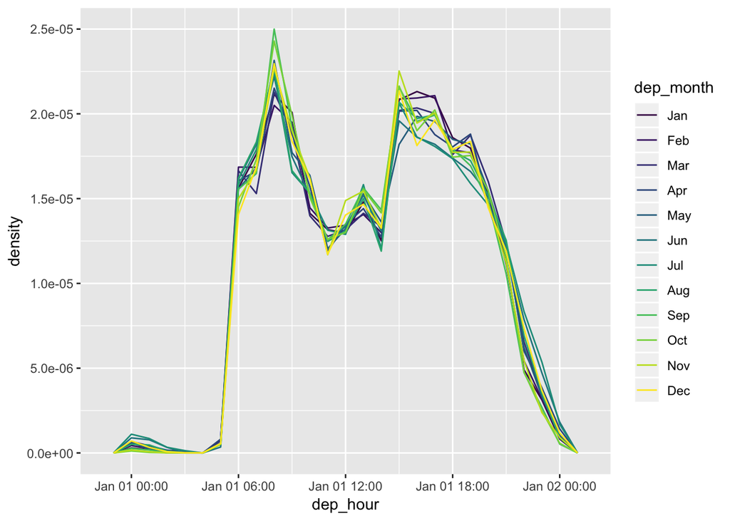

```r
flights_dt %>%
  filter(!is.na(dep_time)) %>%
  mutate(dep_hour = update(dep_time, yday = 1),          #hour of dep_time, assume all day the same (1 Jan)
         dep_month = month(dep_time, label=TRUE)         #extract month of dep_time
         ) %>%

  ggplot(aes(x = dep_hour, color = dep_month)) +
  geom_freqpoly(aes(y = ..density..), binwidth = 3600)
```

## 2. Compare `dep_time`, `sched_dep_time` and `dep_delay`. Are they consistent? Explain your findings.

consistent? u mean `dep_time` always equal to `sched_dep_time` + `dep_delay` so they are not consistent because of delay which can change the date

```r
# Got finding, we have a problem with delay that will change the date
flights_finding <- flights_dt %>%
  mutate(dep_time_actual = sched_dep_time + dep_delay * 60) %>%
  select(sched_dep_time, dep_delay, dep_time, dep_time_actual) %>%
  filter(dep_time != dep_time_actual) %>%
  arrange(dep_delay)

# confirm those finding
flights_finding %>%
  mutate(day_diff = yday(dep_time_actual) - yday(dep_time)) %>%
  filter(day_diff == 0)
```

```
## # A tibble: 0 x 5
## # … with 5 variables: sched_dep_time <dttm>, dep_delay <dbl>,
## #   dep_time <dttm>, dep_time_actual <dttm>, day_diff <dbl>
```

## 3. Compare `air_time` with the duration between the departure and arrival. Explain your findings. (Hint: consider the location of the airport)

the `air_time` will definitely different because of different time zone between two airport

```r
flights_dt %>%
  mutate(
    airtime_calc = arr_time - dep_time,
    airtime_diff = as.numeric(airtime_calc) - air_time
  ) %>%
  select(dep_time, arr_time, air_time, airtime_calc, airtime_diff)
```

```
## # A tibble: 328,063 x 5
##    dep_time            arr_time            air_time airtime_calc
##    <dttm>              <dttm>                 <dbl> <time>
##  1 2013-01-01 05:17:00 2013-01-01 08:30:00      227 193 mins
##  2 2013-01-01 05:33:00 2013-01-01 08:50:00      227 197 mins
##  3 2013-01-01 05:42:00 2013-01-01 09:23:00      160 221 mins
##  4 2013-01-01 05:44:00 2013-01-01 10:04:00      183 260 mins
##  5 2013-01-01 05:54:00 2013-01-01 08:12:00      116 138 mins
##  6 2013-01-01 05:54:00 2013-01-01 07:40:00      150 106 mins
##  7 2013-01-01 05:55:00 2013-01-01 09:13:00      158 198 mins
##  8 2013-01-01 05:57:00 2013-01-01 07:09:00       53  72 mins
##  9 2013-01-01 05:57:00 2013-01-01 08:38:00      140 161 mins
## 10 2013-01-01 05:58:00 2013-01-01 07:53:00      138 115 mins
## # … with 328,053 more rows, and 1 more variable: airtime_diff <dbl>
```

we should calculate the time difference, unfortunately I still can’t find how to convert `08:00:00 UTC` to `08:00:00 EDT` (only the timezone changed) on an array of UTC time and array of timezone strings

```r
replace_tz <- function(x,y){
  for (idx in seq_along(x)) {
    x[idx] <- parse_date_time(x[idx], "%Y-%m-%d %H:%M:%S", tz = y[idx])
  }
}

# flights_tz <- flights_dt %>%
#   select(dep_time, arr_time, air_time, origin, dest) %>%
#   inner_join(
#     select(airports, faa, tzone),
#     by = c('origin' = 'faa')
#     ) %>%
#   rename('origin_tzone' = 'tzone') %>%
#   inner_join(
#     select(airports, faa, tzone),
#     by = c('dest' = 'faa')
#   ) %>%
#   rename('dest_tzone' = 'tzone')
#
```

## 4. How does the average delay time change over the course of a day? Should you use `dep_time` or `sched_dep_time`? Why?

I think it’s better to use `sched_dep_time` because it’s fixed and `dep_time` could be biased by how much delay they got. If the delay is so big, then `dep_time` is not relevant.

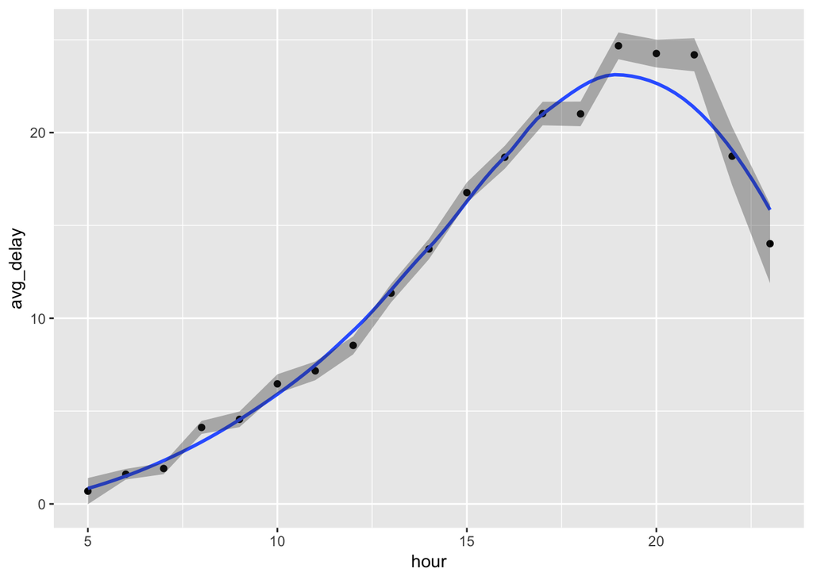

```r
flights_dt %>%
  mutate(
    hour = hour(sched_dep_time)
  ) %>%
  group_by(hour) %>%
  summarise(
    avg_delay = mean(dep_delay),
    sd = sd(dep_delay),
    n = n(),
    conf = 1.96 * sd / sqrt(n)
  ) %>%
  ggplot(aes(x = hour, y = avg_delay)) +
  geom_point() +
  geom_smooth(se = FALSE) +
  geom_ribbon(mapping = aes(ymax = avg_delay + conf, ymin = avg_delay - conf), alpha = 1/3)
```

From the plot we can see that average delay is the highest at around 7-8 pm. It’s make sense because the delay will stacked up from morning and will slowly get better when the flight schedule is not busy anymore.

## 5. On what day of the week should you leave if you want to minimise the chance of a delay?

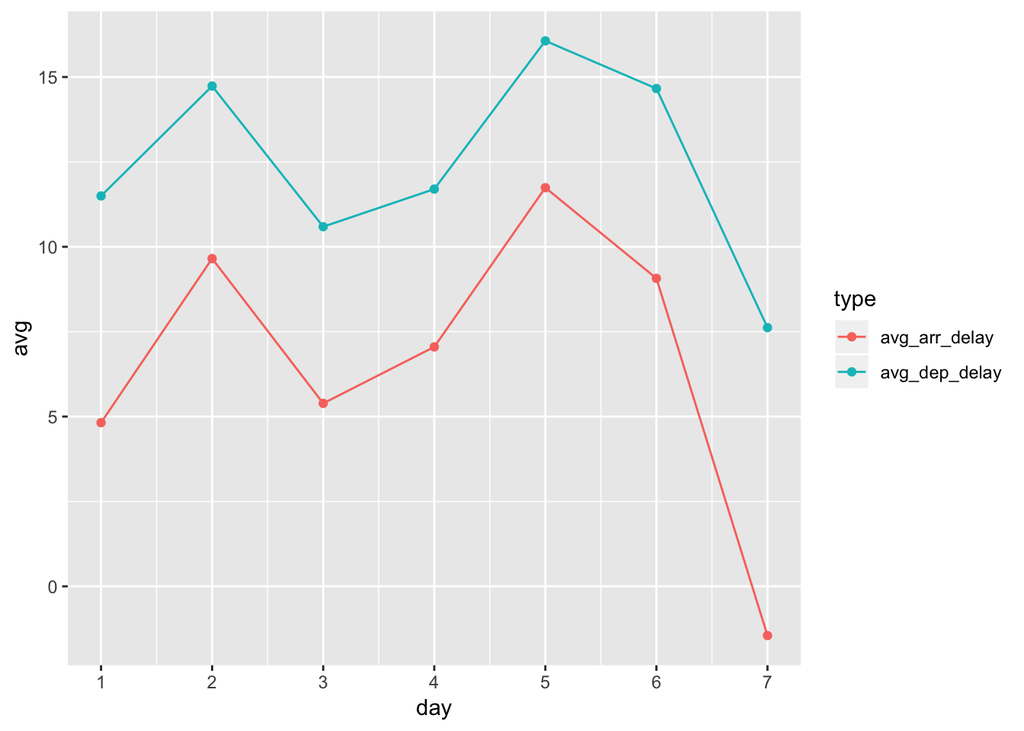

```r
flights_dt %>%
  mutate(
    day = wday(sched_dep_time)
  ) %>%
  group_by(day) %>%
  summarise(
    avg_dep_delay = mean(dep_delay),
    avg_arr_delay = mean(arr_delay, na.rm = TRUE)
  ) %>%
  gather(`avg_dep_delay`:`avg_arr_delay`, key = 'type', value = 'avg') %>%
  ggplot(aes(x = day, y = avg, color = type)) +
    geom_point() + geom_line() +
  scale_x_continuous(breaks = seq(1, 7, 1))
```

The best way to minimize delay is schedule the flight on Saturday

## 6. What makes the distribution of `diamonds$carat` and `flights$sched_dep_time` similar?

I think what makes the distribution similar is because the rounding behaviour in `diamonds$carat` and `flights$sched_dep_time`. On `diamonds$carat`, many diamonds have carat rounded to nearest integer (ex:1,2,3). On `flights$sched_dep_time`, many flights rounded every 5 minutes.

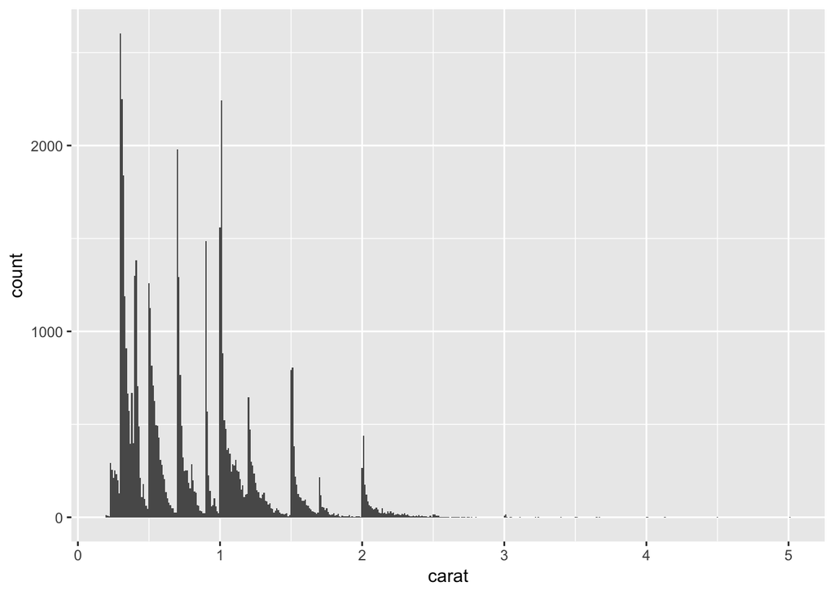

```r
ggplot(diamonds, aes(carat)) +
  geom_histogram(binwidth = 0.01)
```

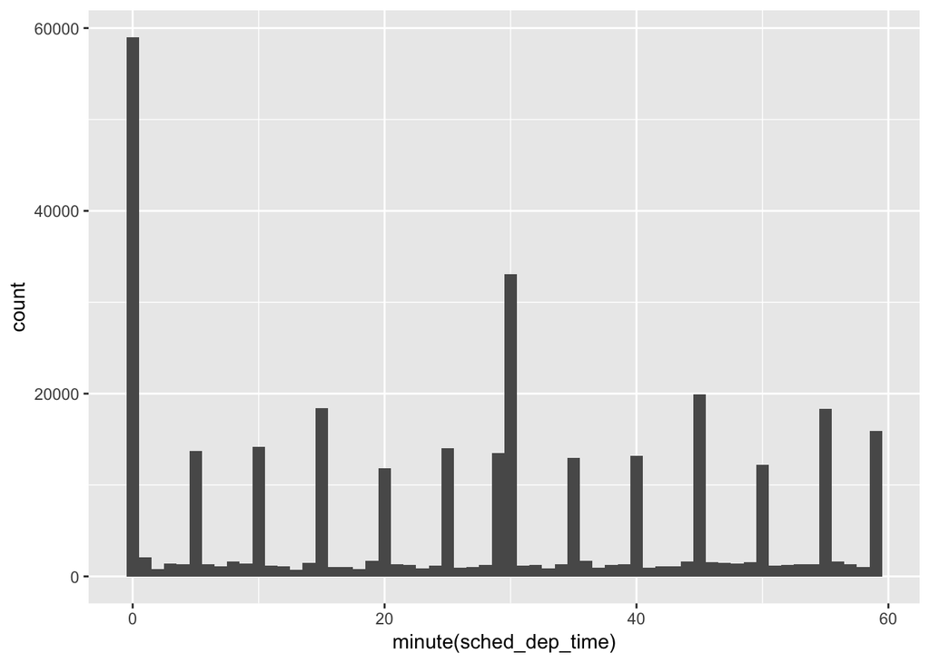

```r
ggplot(flights_dt, aes(minute(sched_dep_time))) +
  geom_histogram(binwidth = 1)
```

## 7. Confirm my hypothesis that the early departures of flights in minutes 20-30 and 50-60 are caused by scheduled flights that leave early. Hint: create a binary variable that tells you whether or not a flight was delayed.

I think it’s not, proportion of flight that leave early on minutes 20-30 and 50-60 is still low compared to minutes 0-10

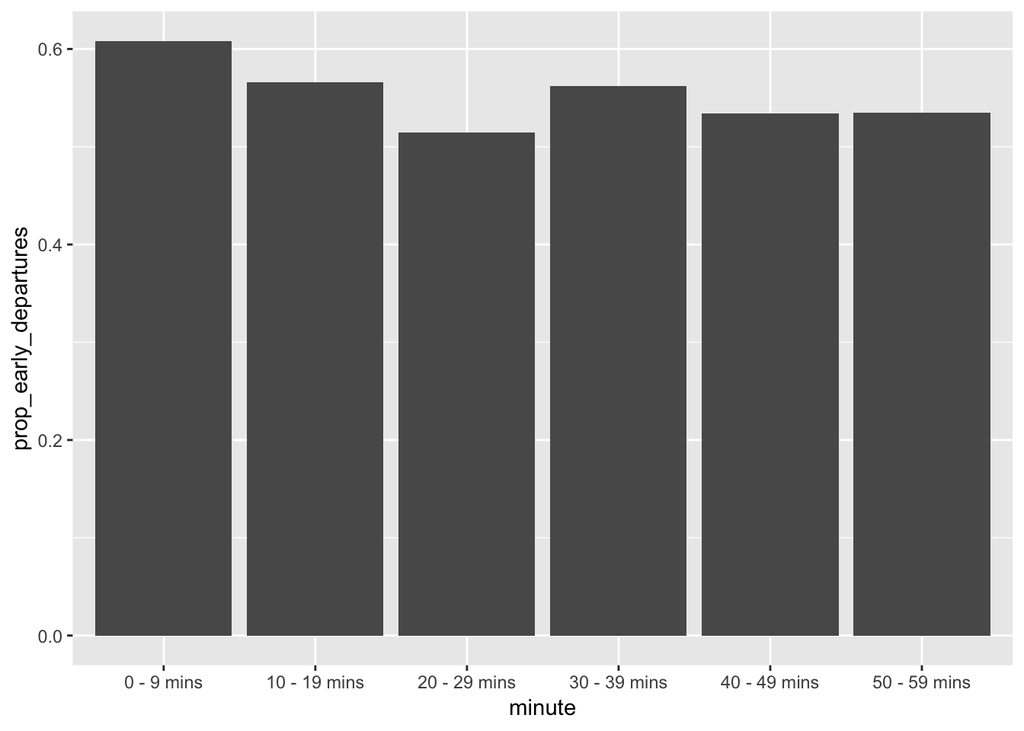

```r
flights_dt %>%
  mutate(
    binary = dep_delay < 0,
    minute = minute(sched_dep_time) %/% 10,
    minute = factor(minute, levels = c(0,1,2,3,4,5),
                          labels = c('0 - 9 mins',
                                     '10 - 19 mins',
                                     '20 - 29 mins',
                                     '30 - 39 mins',
                                     '40 - 49 mins',
                                     '50 - 59 mins'))
  ) %>%
  group_by(minute) %>%
  summarise(
    prop_early_departures = mean(binary)
  ) %>%
  ggplot(aes(minute, prop_early_departures)) +
  geom_col()
```

# ——————- 16.4.5 Exercise ————————-

## 1. Why is there `months()` but no `dmonths()`?

because months cannot specified by duration of seconds. It is caused by there are month with different day span (30, 31, and 28). So, in summary, months is a human period between two dates

## 2. Explain `days(overnight * 1)` to someone who has just started learning R. How does it work?

refering to this chunk

```
flights_dt %>%
  mutate(
    overnight = arr_time < dep_time,
    arr_time = arr_time + days(overnight * 1),
    sched_arr_time = sched_arr_time + days(overnight * 1)
  )
```

overnight is a boolean feature 1: the flight is overnight flight (there are day difference between arrival date and departure date) 0: the flight is not overnight flight

If it’s an overnight flight, the `days()` will output 1 day period, and we have to add 1 day to arrival time

## 3. Create a vector of dates giving the first day of every month in 2015. Create a vector of dates giving the first day of every month in the current year.

```r
ymd(150101) + months(1:11)
```

```
##  [1] "2015-02-01" "2015-03-01" "2015-04-01" "2015-05-01" "2015-06-01"
##  [6] "2015-07-01" "2015-08-01" "2015-09-01" "2015-10-01" "2015-11-01"
## [11] "2015-12-01"
```

```r
ymd(floor_date(today(), unit = 'year')) + months(1:11)
```

```
##  [1] "2019-02-01" "2019-03-01" "2019-04-01" "2019-05-01" "2019-06-01"
##  [6] "2019-07-01" "2019-08-01" "2019-09-01" "2019-10-01" "2019-11-01"
## [11] "2019-12-01"
```

## 4. Write a function that given your birthday (as a date), returns how old you are in years.

```r
age <- function(birthdate) {
  birthdate %--% today() %/% years(1)
}

age(ymd(19961127))
```

```
## Note: method with signature 'Timespan#Timespan' chosen for function '%/%',
##  target signature 'Interval#Period'.
##  "Interval#ANY", "ANY#Period" would also be valid
```

```
## [1] 22
```

## 5. Why can’t `(today() %--% (today() + years(1)) / months(1)` work?

It works, but missing `)`

```r
(today() %--% (today() + years(1)) / months(1))
```

```
## [1] 12
```